# Risk Factor Analysis

## Outcome Variable

**Outcome Variable:** haz

## Predictor Variables

**Intervention Variable:** nhh

**Adjustment Set:**

- arm
- W_mage
- meducyrs
- feducyrs
- hhwealth_quart
- W_mhtcm
- W_mwtkg
- W_mbmi
- W_nrooms
- cleanck
- impfloor
- impsan
- safeh20
- delta_W_mage
- delta_meducyrs
- delta_feducyrs
- delta_hhwealth_quart
- delta_W_mhtcm
- delta_W_mwtkg
- delta_W_mbmi
- delta_W_nrooms
- delta_cleanck
- delta_impfloor
- delta_impsan
- delta_safeh20

## Stratifying Variables

The analysis was stratified on these variable(s):

- agecat
- studyid
- country

## Data Summary

| agecat | studyid | country | nhh | n_cell | n | outcome_variable |
| --- | --- | --- | --- | --- | --- | --- |
| Birth | IRC | INDIA | 3 or less | 54 | 388 | haz |
| Birth | IRC | INDIA | 4-5 | 150 | 388 | haz |
| Birth | IRC | INDIA | 6-7 | 103 | 388 | haz |
| Birth | IRC | INDIA | 8+ | 81 | 388 | haz |
| Birth | NIH-Birth | BANGLADESH | 3 or less | 112 | 608 | haz |
| Birth | NIH-Birth | BANGLADESH | 4-5 | 255 | 608 | haz |
| Birth | NIH-Birth | BANGLADESH | 6-7 | 138 | 608 | haz |
| Birth | NIH-Birth | BANGLADESH | 8+ | 103 | 608 | haz |
| Birth | NIH-Crypto | BANGLADESH | 3 or less | 108 | 732 | haz |
| Birth | NIH-Crypto | BANGLADESH | 4-5 | 328 | 732 | haz |
| Birth | NIH-Crypto | BANGLADESH | 6-7 | 176 | 732 | haz |
| Birth | NIH-Crypto | BANGLADESH | 8+ | 120 | 732 | haz |
| Birth | PROVIDE | BANGLADESH | 3 or less | 104 | 539 | haz |
| Birth | PROVIDE | BANGLADESH | 4-5 | 251 | 539 | haz |
| Birth | PROVIDE | BANGLADESH | 6-7 | 116 | 539 | haz |
| Birth | PROVIDE | BANGLADESH | 8+ | 68 | 539 | haz |
| 6 months | IRC | INDIA | 3 or less | 58 | 407 | haz |
| 6 months | IRC | INDIA | 4-5 | 158 | 407 | haz |
| 6 months | IRC | INDIA | 6-7 | 106 | 407 | haz |
| 6 months | IRC | INDIA | 8+ | 85 | 407 | haz |
| 6 months | LCNI-5 | MALAWI | 3 or less | 224 | 816 | haz |
| 6 months | LCNI-5 | MALAWI | 4-5 | 340 | 816 | haz |
| 6 months | LCNI-5 | MALAWI | 6-7 | 182 | 816 | haz |
| 6 months | LCNI-5 | MALAWI | 8+ | 70 | 816 | haz |
| 6 months | NIH-Birth | BANGLADESH | 3 or less | 95 | 537 | haz |
| 6 months | NIH-Birth | BANGLADESH | 4-5 | 227 | 537 | haz |
| 6 months | NIH-Birth | BANGLADESH | 6-7 | 128 | 537 | haz |
| 6 months | NIH-Birth | BANGLADESH | 8+ | 87 | 537 | haz |
| 6 months | NIH-Crypto | BANGLADESH | 3 or less | 104 | 715 | haz |
| 6 months | NIH-Crypto | BANGLADESH | 4-5 | 326 | 715 | haz |
| 6 months | NIH-Crypto | BANGLADESH | 6-7 | 170 | 715 | haz |
| 6 months | NIH-Crypto | BANGLADESH | 8+ | 115 | 715 | haz |
| 6 months | PROVIDE | BANGLADESH | 3 or less | 105 | 604 | haz |
| 6 months | PROVIDE | BANGLADESH | 4-5 | 289 | 604 | haz |
| 6 months | PROVIDE | BANGLADESH | 6-7 | 130 | 604 | haz |
| 6 months | PROVIDE | BANGLADESH | 8+ | 80 | 604 | haz |
| 6 months | SAS-FoodSuppl | INDIA | 3 or less | 33 | 380 | haz |
| 6 months | SAS-FoodSuppl | INDIA | 4-5 | 166 | 380 | haz |
| 6 months | SAS-FoodSuppl | INDIA | 6-7 | 115 | 380 | haz |
| 6 months | SAS-FoodSuppl | INDIA | 8+ | 66 | 380 | haz |
| 24 months | IRC | INDIA | 3 or less | 58 | 409 | haz |
| 24 months | IRC | INDIA | 4-5 | 158 | 409 | haz |
| 24 months | IRC | INDIA | 6-7 | 107 | 409 | haz |
| 24 months | IRC | INDIA | 8+ | 86 | 409 | haz |
| 24 months | LCNI-5 | MALAWI | 3 or less | 159 | 574 | haz |
| 24 months | LCNI-5 | MALAWI | 4-5 | 237 | 574 | haz |
| 24 months | LCNI-5 | MALAWI | 6-7 | 129 | 574 | haz |
| 24 months | LCNI-5 | MALAWI | 8+ | 49 | 574 | haz |
| 24 months | NIH-Birth | BANGLADESH | 3 or less | 75 | 429 | haz |
| 24 months | NIH-Birth | BANGLADESH | 4-5 | 184 | 429 | haz |
| 24 months | NIH-Birth | BANGLADESH | 6-7 | 100 | 429 | haz |
| 24 months | NIH-Birth | BANGLADESH | 8+ | 70 | 429 | haz |
| 24 months | NIH-Crypto | BANGLADESH | 3 or less | 69 | 514 | haz |
| 24 months | NIH-Crypto | BANGLADESH | 4-5 | 232 | 514 | haz |
| 24 months | NIH-Crypto | BANGLADESH | 6-7 | 130 | 514 | haz |
| 24 months | NIH-Crypto | BANGLADESH | 8+ | 83 | 514 | haz |
| 24 months | PROVIDE | BANGLADESH | 3 or less | 106 | 578 | haz |
| 24 months | PROVIDE | BANGLADESH | 4-5 | 273 | 578 | haz |
| 24 months | PROVIDE | BANGLADESH | 6-7 | 117 | 578 | haz |
| 24 months | PROVIDE | BANGLADESH | 8+ | 82 | 578 | haz |

The following strata were considered:

- agecat: 24 months, studyid: IRC, country: INDIA
- agecat: 24 months, studyid: LCNI-5, country: MALAWI
- agecat: 24 months, studyid: NIH-Birth, country: BANGLADESH
- agecat: 24 months, studyid: NIH-Crypto, country: BANGLADESH
- agecat: 24 months, studyid: PROVIDE, country: BANGLADESH
- agecat: 6 months, studyid: IRC, country: INDIA
- agecat: 6 months, studyid: LCNI-5, country: MALAWI
- agecat: 6 months, studyid: NIH-Birth, country: BANGLADESH
- agecat: 6 months, studyid: NIH-Crypto, country: BANGLADESH
- agecat: 6 months, studyid: PROVIDE, country: BANGLADESH
- agecat: 6 months, studyid: SAS-FoodSuppl, country: INDIA
- agecat: Birth, studyid: IRC, country: INDIA
- agecat: Birth, studyid: NIH-Birth, country: BANGLADESH
- agecat: Birth, studyid: NIH-Crypto, country: BANGLADESH
- agecat: Birth, studyid: PROVIDE, country: BANGLADESH

## Methods Detail

We’re interested in the causal parameters $E[Y_a]$ for all values of $a \in \mathcal{A}$. These parameters represent the mean outcome if, possibly contrary to fact, we intervened to set all units to have $A=a$. Under the randomization and positivity assumptions, these are identified by the statistical parameters $\psi_a=E_W[E_{Y|A,W}(Y|A=a,W)]$. In addition, we’re interested in the mean of $Y$, $E[Y]$ under no intervention (the observed mean). We will estimate these parameters by using SuperLearner to fit the relevant likelihood factors – $E_{Y|A,W}(Y|A=a,W)$ and $p(A=a|W)$, and then updating our likelihood fit using a joint TMLE.

For unadjusted analyses ($W=\{\}$), initial likelihoods were estimated using Lrnr_glm to estimate the simple $E(Y|A)$ and Lrnr_mean to estimate $p(A)$. For adjusted analyses, a small library containing Lrnr_glmnet, Lrnr_xgboost, and Lrnr_mean was used.

# Results Detail

## Results Plots

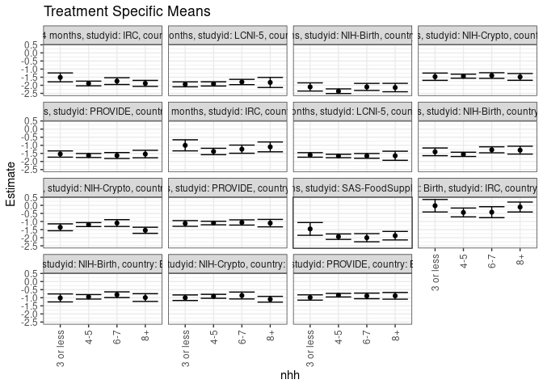

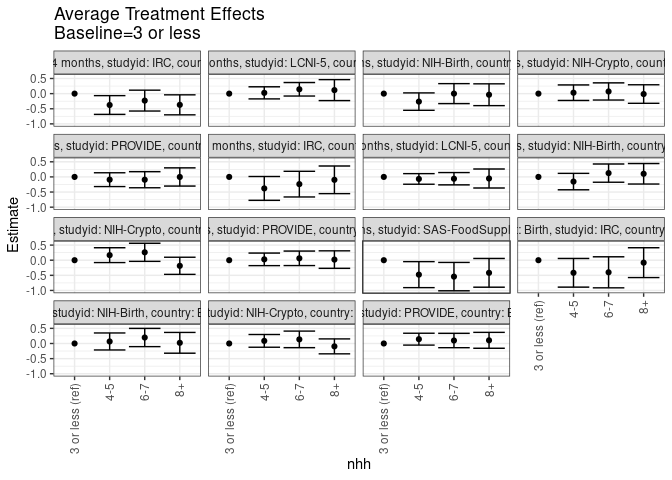

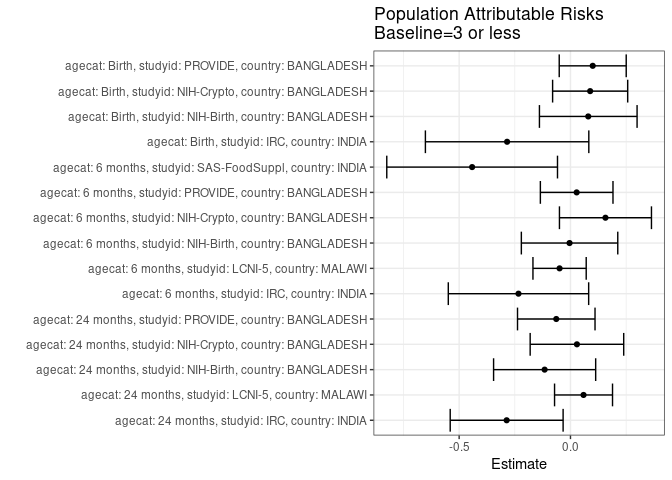

## Results Table

### Parameter: TSM

| agecat | studyid | country | intervention_level | baseline_level | estimate | ci_lower | ci_upper |
| --- | --- | --- | --- | --- | --- | --- | --- |
| Birth | IRC | INDIA | 3 or less | NA | -0.0234253 | -0.4093395 | 0.3624889 |
| Birth | IRC | INDIA | 4-5 | NA | -0.4399820 | -0.7123462 | -0.1676178 |
| Birth | IRC | INDIA | 6-7 | NA | -0.4236205 | -0.7614707 | -0.0857702 |
| Birth | IRC | INDIA | 8+ | NA | -0.1044614 | -0.4112806 | 0.2023577 |
| Birth | NIH-Birth | BANGLADESH | 3 or less | NA | -1.0108610 | -1.2568843 | -0.7648377 |
| Birth | NIH-Birth | BANGLADESH | 4-5 | NA | -0.9438945 | -1.0820247 | -0.8057644 |
| Birth | NIH-Birth | BANGLADESH | 6-7 | NA | -0.8132164 | -0.9892705 | -0.6371623 |
| Birth | NIH-Birth | BANGLADESH | 8+ | NA | -0.9881216 | -1.2267494 | -0.7494937 |
| Birth | NIH-Crypto | BANGLADESH | 3 or less | NA | -0.9978794 | -1.1693178 | -0.8264410 |
| Birth | NIH-Crypto | BANGLADESH | 4-5 | NA | -0.9110010 | -1.0324327 | -0.7895693 |
| Birth | NIH-Crypto | BANGLADESH | 6-7 | NA | -0.8622648 | -1.0748510 | -0.6496786 |
| Birth | NIH-Crypto | BANGLADESH | 8+ | NA | -1.0930810 | -1.2716409 | -0.9145210 |
| Birth | PROVIDE | BANGLADESH | 3 or less | NA | -0.9850062 | -1.1484008 | -0.8216116 |
| Birth | PROVIDE | BANGLADESH | 4-5 | NA | -0.8414125 | -0.9513302 | -0.7314949 |
| Birth | PROVIDE | BANGLADESH | 6-7 | NA | -0.8864178 | -1.0590308 | -0.7138047 |
| Birth | PROVIDE | BANGLADESH | 8+ | NA | -0.8801050 | -1.0868081 | -0.6734018 |
| 6 months | IRC | INDIA | 3 or less | NA | -1.0008798 | -1.3423065 | -0.6594532 |
| 6 months | IRC | INDIA | 4-5 | NA | -1.3809651 | -1.5780673 | -1.1838629 |
| 6 months | IRC | INDIA | 6-7 | NA | -1.2391595 | -1.4913334 | -0.9869856 |
| 6 months | IRC | INDIA | 8+ | NA | -1.0970049 | -1.4008515 | -0.7931582 |
| 6 months | LCNI-5 | MALAWI | 3 or less | NA | -1.5937460 | -1.7343548 | -1.4531372 |
| 6 months | LCNI-5 | MALAWI | 4-5 | NA | -1.6603524 | -1.7663241 | -1.5543807 |
| 6 months | LCNI-5 | MALAWI | 6-7 | NA | -1.6533072 | -1.8005671 | -1.5060472 |
| 6 months | LCNI-5 | MALAWI | 8+ | NA | -1.6458845 | -1.9268241 | -1.3649449 |
| 6 months | NIH-Birth | BANGLADESH | 3 or less | NA | -1.4032513 | -1.6413512 | -1.1651513 |
| 6 months | NIH-Birth | BANGLADESH | 4-5 | NA | -1.5572265 | -1.6887500 | -1.4257030 |
| 6 months | NIH-Birth | BANGLADESH | 6-7 | NA | -1.2774021 | -1.4628576 | -1.0919466 |
| 6 months | NIH-Birth | BANGLADESH | 8+ | NA | -1.2997397 | -1.5416988 | -1.0577806 |
| 6 months | NIH-Crypto | BANGLADESH | 3 or less | NA | -1.3557683 | -1.5675496 | -1.1439870 |
| 6 months | NIH-Crypto | BANGLADESH | 4-5 | NA | -1.1884863 | -1.3120391 | -1.0649335 |
| 6 months | NIH-Crypto | BANGLADESH | 6-7 | NA | -1.0946978 | -1.3054073 | -0.8839882 |
| 6 months | NIH-Crypto | BANGLADESH | 8+ | NA | -1.5413427 | -1.7296796 | -1.3530059 |
| 6 months | PROVIDE | BANGLADESH | 3 or less | NA | -1.1195286 | -1.2961407 | -0.9429166 |
| 6 months | PROVIDE | BANGLADESH | 4-5 | NA | -1.0916229 | -1.2010879 | -0.9821579 |
| 6 months | PROVIDE | BANGLADESH | 6-7 | NA | -1.0570834 | -1.2190239 | -0.8951430 |
| 6 months | PROVIDE | BANGLADESH | 8+ | NA | -1.0991792 | -1.3284402 | -0.8699183 |
| 6 months | SAS-FoodSuppl | INDIA | 3 or less | NA | -1.4569971 | -1.8516866 | -1.0623077 |
| 6 months | SAS-FoodSuppl | INDIA | 4-5 | NA | -1.9342730 | -2.1028776 | -1.7656683 |
| 6 months | SAS-FoodSuppl | INDIA | 6-7 | NA | -1.9996764 | -2.2508245 | -1.7485283 |
| 6 months | SAS-FoodSuppl | INDIA | 8+ | NA | -1.8742867 | -2.1367916 | -1.6117819 |
| 24 months | IRC | INDIA | 3 or less | NA | -1.5121572 | -1.7862944 | -1.2380201 |
| 24 months | IRC | INDIA | 4-5 | NA | -1.8884751 | -2.0337594 | -1.7431908 |
| 24 months | IRC | INDIA | 6-7 | NA | -1.7427927 | -1.9514487 | -1.5341368 |
| 24 months | IRC | INDIA | 8+ | NA | -1.8826426 | -2.0663068 | -1.6989784 |
| 24 months | LCNI-5 | MALAWI | 3 or less | NA | -1.9409313 | -2.0922779 | -1.7895847 |
| 24 months | LCNI-5 | MALAWI | 4-5 | NA | -1.9147668 | -2.0449193 | -1.7846143 |
| 24 months | LCNI-5 | MALAWI | 6-7 | NA | -1.7968410 | -1.9605925 | -1.6330894 |
| 24 months | LCNI-5 | MALAWI | 8+ | NA | -1.8248459 | -2.1363789 | -1.5133130 |
| 24 months | NIH-Birth | BANGLADESH | 3 or less | NA | -2.1029686 | -2.3556934 | -1.8502438 |
| 24 months | NIH-Birth | BANGLADESH | 4-5 | NA | -2.3666940 | -2.5099078 | -2.2234802 |
| 24 months | NIH-Birth | BANGLADESH | 6-7 | NA | -2.1021251 | -2.3201845 | -1.8840657 |
| 24 months | NIH-Birth | BANGLADESH | 8+ | NA | -2.1392985 | -2.3992986 | -1.8792985 |
| 24 months | NIH-Crypto | BANGLADESH | 3 or less | NA | -1.4702574 | -1.6948002 | -1.2457146 |
| 24 months | NIH-Crypto | BANGLADESH | 4-5 | NA | -1.4395680 | -1.5646591 | -1.3144770 |
| 24 months | NIH-Crypto | BANGLADESH | 6-7 | NA | -1.3986454 | -1.5727995 | -1.2244914 |
| 24 months | NIH-Crypto | BANGLADESH | 8+ | NA | -1.4837517 | -1.6921111 | -1.2753922 |
| 24 months | PROVIDE | BANGLADESH | 3 or less | NA | -1.5386110 | -1.7317750 | -1.3454471 |
| 24 months | PROVIDE | BANGLADESH | 4-5 | NA | -1.6290421 | -1.7513555 | -1.5067287 |
| 24 months | PROVIDE | BANGLADESH | 6-7 | NA | -1.6310096 | -1.8145567 | -1.4474625 |
| 24 months | PROVIDE | BANGLADESH | 8+ | NA | -1.5403430 | -1.7714085 | -1.3092775 |

### Parameter: E(Y)

| agecat | studyid | country | intervention_level | baseline_level | estimate | ci_lower | ci_upper |
| --- | --- | --- | --- | --- | --- | --- | --- |
| Birth | IRC | INDIA | NA | NA | -0.3080412 | -0.4687931 | -0.1472894 |
| Birth | NIH-Birth | BANGLADESH | NA | NA | -0.9310197 | -1.0197391 | -0.8423003 |
| Birth | NIH-Crypto | BANGLADESH | NA | NA | -0.9094945 | -0.9809370 | -0.8380521 |
| Birth | PROVIDE | BANGLADESH | NA | NA | -0.8851020 | -0.9601332 | -0.8100709 |
| 6 months | IRC | INDIA | NA | NA | -1.2344062 | -1.3658524 | -1.1029600 |
| 6 months | LCNI-5 | MALAWI | NA | NA | -1.6426961 | -1.7120603 | -1.5733318 |
| 6 months | NIH-Birth | BANGLADESH | NA | NA | -1.4073821 | -1.4960598 | -1.3187043 |
| 6 months | NIH-Crypto | BANGLADESH | NA | NA | -1.1986783 | -1.2700937 | -1.1272630 |
| 6 months | PROVIDE | BANGLADESH | NA | NA | -1.0916915 | -1.1661176 | -1.0172654 |
| 6 months | SAS-FoodSuppl | INDIA | NA | NA | -1.8986842 | -2.0118892 | -1.7854792 |
| 24 months | IRC | INDIA | NA | NA | -1.7987775 | -1.8923914 | -1.7051636 |
| 24 months | LCNI-5 | MALAWI | NA | NA | -1.8822648 | -1.9637218 | -1.8008078 |
| 24 months | NIH-Birth | BANGLADESH | NA | NA | -2.2190579 | -2.3217459 | -2.1163699 |
| 24 months | NIH-Crypto | BANGLADESH | NA | NA | -1.4412646 | -1.5249156 | -1.3576135 |
| 24 months | PROVIDE | BANGLADESH | NA | NA | -1.6024221 | -1.6857420 | -1.5191023 |

### Parameter: ATE

| agecat | studyid | country | intervention_level | baseline_level | estimate | ci_lower | ci_upper |
| --- | --- | --- | --- | --- | --- | --- | --- |
| Birth | IRC | INDIA | 3 or less | 3 or less | 0.0000000 | 0.0000000 | 0.0000000 |
| Birth | IRC | INDIA | 4-5 | 3 or less | -0.4165567 | -0.8904351 | 0.0573217 |
| Birth | IRC | INDIA | 6-7 | 3 or less | -0.4001952 | -0.9129404 | 0.1125501 |
| Birth | IRC | INDIA | 8+ | 3 or less | -0.0810361 | -0.5746408 | 0.4125686 |
| Birth | NIH-Birth | BANGLADESH | 3 or less | 3 or less | 0.0000000 | 0.0000000 | 0.0000000 |
| Birth | NIH-Birth | BANGLADESH | 4-5 | 3 or less | 0.0669665 | -0.2146042 | 0.3485371 |
| Birth | NIH-Birth | BANGLADESH | 6-7 | 3 or less | 0.1976446 | -0.1039226 | 0.4992118 |
| Birth | NIH-Birth | BANGLADESH | 8+ | 3 or less | 0.0227394 | -0.3207037 | 0.3661825 |
| Birth | NIH-Crypto | BANGLADESH | 3 or less | 3 or less | 0.0000000 | 0.0000000 | 0.0000000 |
| Birth | NIH-Crypto | BANGLADESH | 4-5 | 3 or less | 0.0868784 | -0.1233732 | 0.2971300 |
| Birth | NIH-Crypto | BANGLADESH | 6-7 | 3 or less | 0.1356147 | -0.1377678 | 0.4089972 |
| Birth | NIH-Crypto | BANGLADESH | 8+ | 3 or less | -0.0952015 | -0.3425775 | 0.1521744 |
| Birth | PROVIDE | BANGLADESH | 3 or less | 3 or less | 0.0000000 | 0.0000000 | 0.0000000 |
| Birth | PROVIDE | BANGLADESH | 4-5 | 3 or less | 0.1435937 | -0.0528028 | 0.3399901 |
| Birth | PROVIDE | BANGLADESH | 6-7 | 3 or less | 0.0985884 | -0.1384488 | 0.3356257 |
| Birth | PROVIDE | BANGLADESH | 8+ | 3 or less | 0.1049013 | -0.1581545 | 0.3679570 |
| 6 months | IRC | INDIA | 3 or less | 3 or less | 0.0000000 | 0.0000000 | 0.0000000 |
| 6 months | IRC | INDIA | 4-5 | 3 or less | -0.3800852 | -0.7740907 | 0.0139203 |
| 6 months | IRC | INDIA | 6-7 | 3 or less | -0.2382797 | -0.6624223 | 0.1858630 |
| 6 months | IRC | INDIA | 8+ | 3 or less | -0.0961250 | -0.5531006 | 0.3608505 |
| 6 months | LCNI-5 | MALAWI | 3 or less | 3 or less | 0.0000000 | 0.0000000 | 0.0000000 |
| 6 months | LCNI-5 | MALAWI | 4-5 | 3 or less | -0.0666064 | -0.2424495 | 0.1092367 |
| 6 months | LCNI-5 | MALAWI | 6-7 | 3 or less | -0.0595612 | -0.2629907 | 0.1438684 |
| 6 months | LCNI-5 | MALAWI | 8+ | 3 or less | -0.0521385 | -0.3661059 | 0.2618288 |
| 6 months | NIH-Birth | BANGLADESH | 3 or less | 3 or less | 0.0000000 | 0.0000000 | 0.0000000 |
| 6 months | NIH-Birth | BANGLADESH | 4-5 | 3 or less | -0.1539753 | -0.4259461 | 0.1179956 |
| 6 months | NIH-Birth | BANGLADESH | 6-7 | 3 or less | 0.1258491 | -0.1752500 | 0.4269483 |
| 6 months | NIH-Birth | BANGLADESH | 8+ | 3 or less | 0.1035116 | -0.2352894 | 0.4423125 |
| 6 months | NIH-Crypto | BANGLADESH | 3 or less | 3 or less | 0.0000000 | 0.0000000 | 0.0000000 |
| 6 months | NIH-Crypto | BANGLADESH | 4-5 | 3 or less | 0.1672820 | -0.0779117 | 0.4124757 |
| 6 months | NIH-Crypto | BANGLADESH | 6-7 | 3 or less | 0.2610705 | -0.0380214 | 0.5601624 |
| 6 months | NIH-Crypto | BANGLADESH | 8+ | 3 or less | -0.1855745 | -0.4689031 | 0.0977542 |
| 6 months | PROVIDE | BANGLADESH | 3 or less | 3 or less | 0.0000000 | 0.0000000 | 0.0000000 |
| 6 months | PROVIDE | BANGLADESH | 4-5 | 3 or less | 0.0279057 | -0.1798950 | 0.2357065 |
| 6 months | PROVIDE | BANGLADESH | 6-7 | 3 or less | 0.0624452 | -0.1771732 | 0.3020636 |
| 6 months | PROVIDE | BANGLADESH | 8+ | 3 or less | 0.0203494 | -0.2691341 | 0.3098329 |
| 6 months | SAS-FoodSuppl | INDIA | 3 or less | 3 or less | 0.0000000 | 0.0000000 | 0.0000000 |
| 6 months | SAS-FoodSuppl | INDIA | 4-5 | 3 or less | -0.4772758 | -0.9068204 | -0.0477312 |
| 6 months | SAS-FoodSuppl | INDIA | 6-7 | 3 or less | -0.5426792 | -1.0115508 | -0.0738077 |
| 6 months | SAS-FoodSuppl | INDIA | 8+ | 3 or less | -0.4172896 | -0.8921576 | 0.0575783 |
| 24 months | IRC | INDIA | 3 or less | 3 or less | 0.0000000 | 0.0000000 | 0.0000000 |
| 24 months | IRC | INDIA | 4-5 | 3 or less | -0.3763179 | -0.6865955 | -0.0660402 |
| 24 months | IRC | INDIA | 6-7 | 3 or less | -0.2306355 | -0.5749969 | 0.1137259 |
| 24 months | IRC | INDIA | 8+ | 3 or less | -0.3704854 | -0.7004714 | -0.0404994 |
| 24 months | LCNI-5 | MALAWI | 3 or less | 3 or less | 0.0000000 | 0.0000000 | 0.0000000 |
| 24 months | LCNI-5 | MALAWI | 4-5 | 3 or less | 0.0261645 | -0.1736612 | 0.2259901 |
| 24 months | LCNI-5 | MALAWI | 6-7 | 3 or less | 0.1440903 | -0.0790117 | 0.3671923 |
| 24 months | LCNI-5 | MALAWI | 8+ | 3 or less | 0.1160854 | -0.2302285 | 0.4623992 |
| 24 months | NIH-Birth | BANGLADESH | 3 or less | 3 or less | 0.0000000 | 0.0000000 | 0.0000000 |
| 24 months | NIH-Birth | BANGLADESH | 4-5 | 3 or less | -0.2637254 | -0.5518730 | 0.0244222 |
| 24 months | NIH-Birth | BANGLADESH | 6-7 | 3 or less | 0.0008435 | -0.3294801 | 0.3311671 |
| 24 months | NIH-Birth | BANGLADESH | 8+ | 3 or less | -0.0363300 | -0.3962666 | 0.3236066 |
| 24 months | NIH-Crypto | BANGLADESH | 3 or less | 3 or less | 0.0000000 | 0.0000000 | 0.0000000 |
| 24 months | NIH-Crypto | BANGLADESH | 4-5 | 3 or less | 0.0306894 | -0.2259797 | 0.2873585 |
| 24 months | NIH-Crypto | BANGLADESH | 6-7 | 3 or less | 0.0716120 | -0.2122859 | 0.3555098 |
| 24 months | NIH-Crypto | BANGLADESH | 8+ | 3 or less | -0.0134943 | -0.3196184 | 0.2926299 |
| 24 months | PROVIDE | BANGLADESH | 3 or less | 3 or less | 0.0000000 | 0.0000000 | 0.0000000 |
| 24 months | PROVIDE | BANGLADESH | 4-5 | 3 or less | -0.0904310 | -0.3185373 | 0.1376752 |
| 24 months | PROVIDE | BANGLADESH | 6-7 | 3 or less | -0.0923986 | -0.3585133 | 0.1737161 |
| 24 months | PROVIDE | BANGLADESH | 8+ | 3 or less | -0.0017320 | -0.3027043 | 0.2992404 |

### Parameter: PAR

| agecat | studyid | country | intervention_level | baseline_level | estimate | ci_lower | ci_upper |
| --- | --- | --- | --- | --- | --- | --- | --- |
| Birth | IRC | INDIA | 3 or less | NA | -0.2846159 | -0.6515875 | 0.0823556 |
| Birth | NIH-Birth | BANGLADESH | 3 or less | NA | 0.0798412 | -0.1394287 | 0.2991112 |
| Birth | NIH-Crypto | BANGLADESH | 3 or less | NA | 0.0883849 | -0.0802499 | 0.2570197 |
| Birth | PROVIDE | BANGLADESH | 3 or less | NA | 0.0999042 | -0.0505344 | 0.2503428 |
| 6 months | IRC | INDIA | 3 or less | NA | -0.2335264 | -0.5487454 | 0.0816926 |
| 6 months | LCNI-5 | MALAWI | 3 or less | NA | -0.0489501 | -0.1685469 | 0.0706468 |
| 6 months | NIH-Birth | BANGLADESH | 3 or less | NA | -0.0041308 | -0.2206482 | 0.2123866 |
| 6 months | NIH-Crypto | BANGLADESH | 3 or less | NA | 0.1570899 | -0.0495326 | 0.3637125 |
| 6 months | PROVIDE | BANGLADESH | 3 or less | NA | 0.0278371 | -0.1352406 | 0.1909149 |
| 6 months | SAS-FoodSuppl | INDIA | 3 or less | NA | -0.4416871 | -0.8250729 | -0.0583013 |
| 24 months | IRC | INDIA | 3 or less | NA | -0.2866203 | -0.5401624 | -0.0330781 |
| 24 months | LCNI-5 | MALAWI | 3 or less | NA | 0.0586665 | -0.0715015 | 0.1888344 |
| 24 months | NIH-Birth | BANGLADESH | 3 or less | NA | -0.1160893 | -0.3453314 | 0.1131528 |
| 24 months | NIH-Crypto | BANGLADESH | 3 or less | NA | 0.0289928 | -0.1810586 | 0.2390442 |
| 24 months | PROVIDE | BANGLADESH | 3 or less | NA | -0.0638111 | -0.2378715 | 0.1102493 |